# WikiData Processing: European Biographical Data

Julia Ulziisaikhan

6/15/2022

```r
library(tidyverse)
```

```r
library(ggplot2)
library(readxl)
library(janitor)
path <- "C:/Users/ulzii/OneDrive/Documents/spring22/tuttle/wikidata_analysis"
setwd(path)
```

# Data Processing

Our lifespan column is calculated from subtracting the person’s birth year from the death year. We exclude persons with lifespans less than 0.

```r
#functions
blank2na <- function(field){
  output <- ifelse(field=="", NA, field)
  return(output)
}

raw2df <- function(dat){
  df <-
    dat %>%
    clean_names() %>%
    mutate(age = yod - yob,
           occupation_label=blank2na(occupation_label),
           citizen_label=blank2na(citizen_label),
           birthcountry_label = blank2na(birthcountry_label)
           ) %>%
    filter(!is.na(age)) %>%
    filter(age>=0) %>%
    group_by(item) %>%
    slice(1) %>%
    ungroup() %>%
    relocate(age, .after=yod) %>%
    relocate(item, .after=birthcountry_label) %>%
    arrange(yob)
  return(df)
}
```

```r
#load in data
france <- read.csv("data/france_query.csv")
germany <- read.csv("data/germany_query.csv")
russia <- read.csv("data/russia_query.csv")
italy <- read.csv("data/italy_query.csv")
uk <- read.csv("data/uk_query.csv")
spain <- read.csv("data/spain_query.csv")
greece <- read.csv("data/greece_query.csv")
portugal <- read.csv("data/portugal_query.csv")
```

```r
df <- rbind(raw2df(france),
            raw2df(germany),
            raw2df(russia),
            raw2df(italy),
            raw2df(uk),
            raw2df(spain),
            raw2df(greece),
            raw2df(portugal))
```

```r
colnames(raw2df(france))
```

```
## [1] "item_label"         "yob"                "yod"
## [4] "age"                "occupation_label"   "citizen_label"
## [7] "birthcountry_label" "item"
```

We remove the country of citizenship column and instead assign country of birth as the person’s associated country. `id` refers to the WikiData link for the given person’s entry.

```r
df$citizen_label <- NULL
colnames(df) <- c("name", "birth", "death", "lifespan", "occupation", "country", "id")
df$dataset <- "wikidata"
head(df)
```

```
## # A tibble: 6 x 8
##   name         birth death lifespan occupation   country   id            dataset
##   <chr>        <int> <int>    <int> <chr>        <chr>     <chr>         <chr>
## 1 HÃ¦dde         600   705      105 Catholic pr~ United K~ http://www.w~ wikida~
## 2 Birinus        600   650       50 priest       France    http://www.w~ wikida~
## 3 Angelomus o~   780   855       75 monk         France    http://www.w~ wikida~
## 4 Aymard of C~   910   965       55 <NA>         France    http://www.w~ wikida~
## 5 Wichburg       960  1030       70 <NA>         France    http://www.w~ wikida~
## 6 Geoffrey II~  1000  1046       46 aristocrat   France    http://www.w~ wikida~
```

# Exporting Data to .csv

```r
write.csv(df,"wikidata_processed.csv", row.names = FALSE)
```

# Data Quality and Exploration

```r
dim(df)
```

```
## [1] 2921    8
```

```r
range(df$birth)
```

```
## [1] -800 2010
```

```r
range(df$death)
```

```
## [1] -760 2038
```

```r
range(df$lifespan)
```

```
## [1]   0 200
```

There are 2,921 persons in our European persons data set. The minimum and maximum values for the birth year column are -800 and 2010, and -760 and 2038 for the death year column. The quality of the data is questionable, as there is a person with a death year of 2038, which is not in the past. In addition, I display the entries with a lifespan of 0 below. The birth and death years for most of them seem too conveniently located at the start of each century, and their birth and death year information is questionable as the occupations indicate they should at least be adults or children, not persons of lifespan of 0 years.

```r
filter(df, lifespan==0)
```

```
## # A tibble: 17 x 8
##    name        birth death lifespan occupation   country  id             dataset
##    <chr>       <int> <int>    <int> <chr>        <chr>    <chr>          <chr>
##  1 Amaro        1300  1300        0 pilgrim      France   http://www.wi~ wikida~
##  2 Julien Bor~  1700  1700        0 chronicler   France   http://www.wi~ wikida~
##  3 Q16719798    1800  1800        0 opera singer France   http://www.wi~ wikida~
##  4 William Ga~  1801  1801        0 lithographer France   http://www.wi~ wikida~
##  5 Aline Marn~  2000  2000        0 film actor   France   http://www.wi~ wikida~
##  6 Yitzhak Sa~  1500  1500        0 <NA>         Germany  http://www.wi~ wikida~
##  7 Paul of Na~   300   300        0 priest       Italy    http://www.wi~ wikida~
##  8 Austromoine   300   300        0 Catholic pr~ Italy    http://www.wi~ wikida~
##  9 Gaius Juli~   400   400        0 writer       Italy    http://www.wi~ wikida~
## 10 Kate Serje~  1918  1918        0 actor        United ~ http://www.wi~ wikida~
## 11 Juan de Es~  1550  1550        0 painter      Spain    http://www.wi~ wikida~
## 12 Isabel Rod~  1600  1600        0 physician    Spain    http://www.wi~ wikida~
## 13 RamÃ³n PÃ©~  2000  2000        0 writer       Spain    http://www.wi~ wikida~
## 14 Saevius Ni~  -250  -250        0 grammarian   Greece   http://www.wi~ wikida~
## 15 Prosdocimus   100   100        0 Catholic pr~ Greece   http://www.wi~ wikida~
## 16 Lopo de Al~  1400  1400        0 politician   Portugal http://www.wi~ wikida~
## 17 JerÃ³nimo ~  1900  1900        0 illustrator  Portugal http://www.wi~ wikida~
```

There are 421 different occupations in the dataset. The most common ones are painter, actor, Catholic priest, military personnel, and politician. The possibility of overlap between the occupation labels, or synonymous terms, have not been explored here (eg. I noticed the labels “priest” and “Catholic priest” in the data)

```r
length(unique(df$occupation))
```

```
## [1] 421
```

```r
df %>%
  filter(!is.na(occupation)) %>%
  group_by(occupation) %>%
  summarise(count = n()) %>%
  arrange(-count) %>%
  top_n(n = 5, wt = count)
```

```
## # A tibble: 5 x 2
##   occupation         count
##   <chr>              <int>
## 1 painter              161
## 2 actor                160
## 3 Catholic priest      146
## 4 military personnel   146
## 5 politician           144
```

The majority of the persons come from (more specifically, were born in) Germany, France, and the UK.

```r
df %>%
  group_by(country) %>%
  summarise(count = n()) %>%
  arrange(-count) %>%
  top_n(n = 8, wt = count)
```

```
## # A tibble: 8 x 2
##   country        count
##   <chr>          <int>
## 1 Germany          712
## 2 France           614
## 3 United Kingdom   438
## 4 Italy            377
## 5 Spain            285
## 6 Russia           261
## 7 Portugal         143
## 8 Greece            90
```

# Example Plot

A scatter plot of the data, with a moving average line in blue. We limit the x-axis to [1500,2022] as most of the data is concentrated in that timeframe. We limit the upper bound to 120, as lifespans above 120 may seem nonsensical.

```r
plot <-
  ggplot(data=df, aes(x=death, y=lifespan)) +
  geom_point(alpha=0.2) +
  ggtitle("European Lifespans") +
  theme_bw()  +
  ylab("Lifespan") +
  scale_x_continuous(breaks = seq(-800, max(df$death), 200), name = "Year of Death")
```

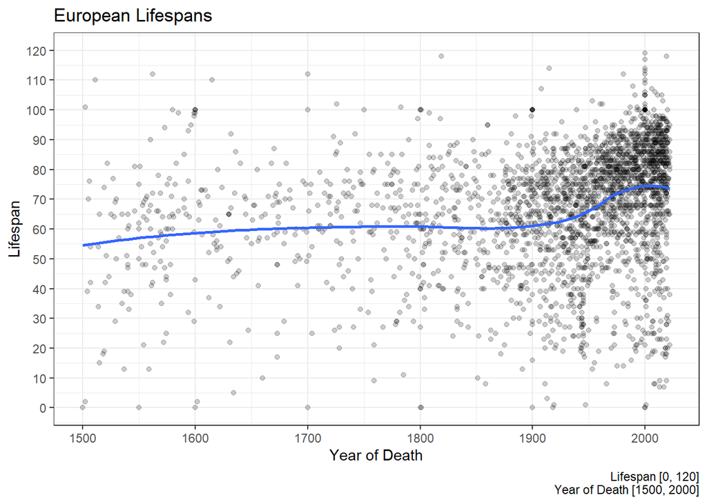

```r
plot +
  scale_x_continuous(breaks = seq(1000, 2000, 100), limits=c(1500,2022), name = "Year of Death") +
  scale_y_continuous(breaks = seq(0, 120, 10), limits=c(0,120)) +
  geom_smooth(method="loess", se = FALSE) +
  labs(caption = "Lifespan [0, 120]\nYear of Death [1500, 2000]")
```